# Log transform

Zihan Fang

10/9/2020

# 1 Introduction

In this blog, I will answer a series of questions related to the transformation of data. I will use both analytic methods and simulation to answer the questions.

## 1.1 Background

It is common in the analysis of biological data to log transform data representing concentrations or data representing dose response.

# 2 Methods

## 2.1 Part 1

- For each distribution below, generate a figure of the PDF and CDF. Mark the mean and median in the figure.

  *X*∼GAMMA(shape=3,scale=1)

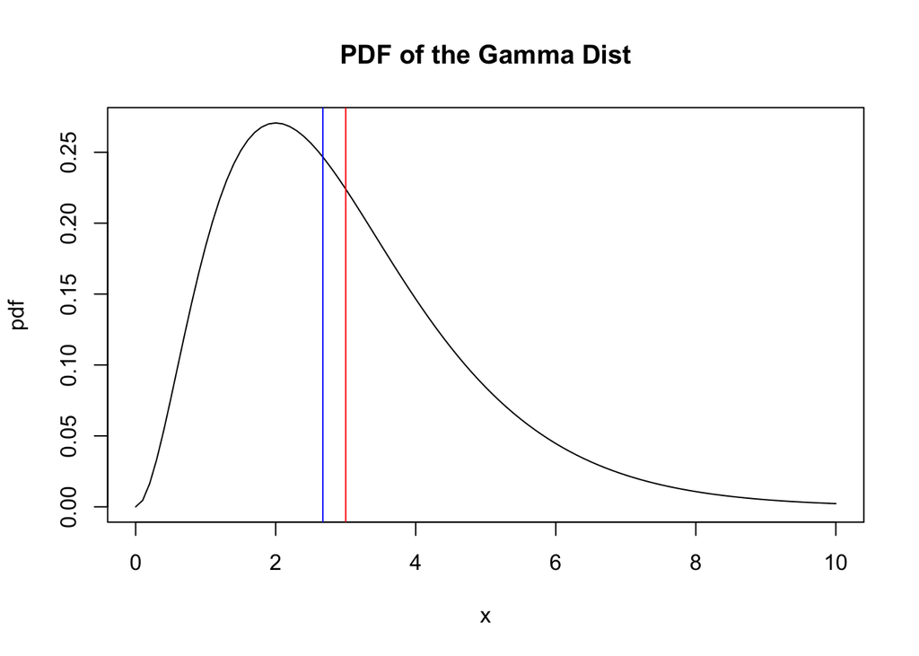

```r
sha=3
sca=1
x=seq(0,10,by=0.1)

pdf=dgamma(x, shape=sha,scale = sca)
mean.gam = sha*sca
median.gam = qgamma(0.5,shape=sha,scale=sca)
plot(x,pdf,main  = "PDF of the Gamma Dist",type = "l")
abline (v=mean.gam,col="red")
abline (v=median.gam,col="blue")
```

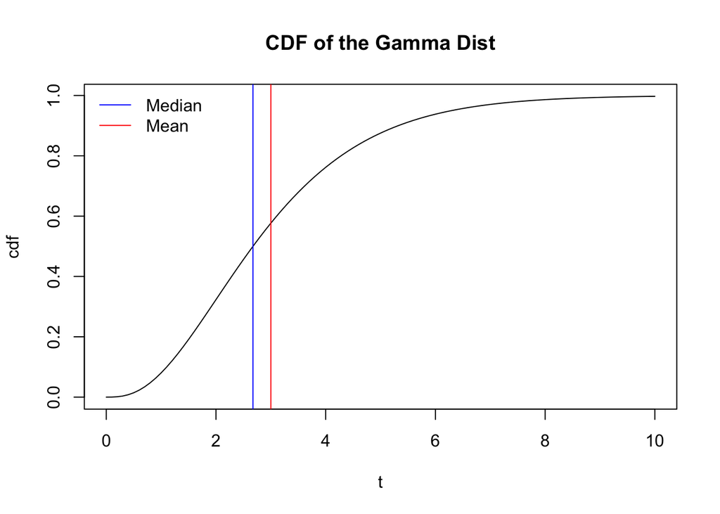

```r
t=seq(0,10,by=0.1)
cdf=pgamma(t, shape=sha,scale = sca)
mean.gam = sha*sca
median.gam = qgamma(0.5,shape=sha,scale=sca)
plot(t,cdf,main  = "CDF of the Gamma Dist",type = "l")
abline (v=mean.gam,col="red")
abline (v=median.gam,col="blue")
legend("topleft",c("Median","Mean"), col = c("blue","red"), lwd = 1, bty = "n")
```

To draw figures of the PDF and CDF of GAMMA(shape=3,scale=1), I first assign x a sequence randomly, then I use `dgamma` to plot PDF and `pgamma` to plot CDF. I use the method shape*scale to calculate the mean of GAMMA(shape=3,scale=1), and `qgamma` to get the median.

```
*X*∼LOG NORMAL(*μ*=−1,*σ*=1)
```

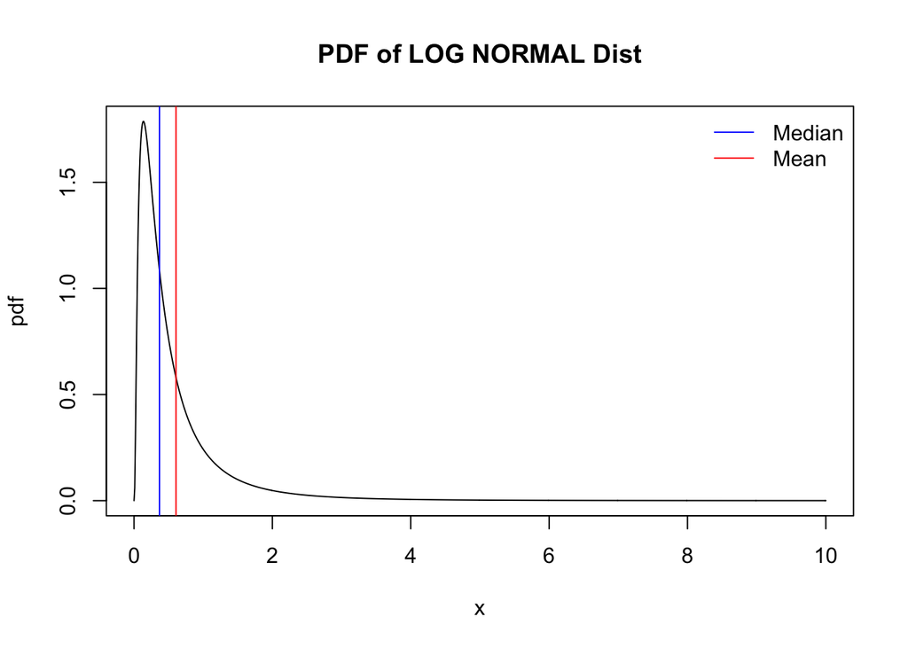

```r
x=seq(0,10,by=0.01)

pdf=dlnorm(x,-1,1)
mean.log = exp(-1+1^2/2)
median.log = qlnorm(0.5,-1,1)
plot(x,pdf,main  = "PDF of LOG NORMAL Dist",type = "l")
abline (v=mean.log,col="red")
abline (v=median.log,col="blue")
legend("topright",c("Median","Mean"), col = c("blue","red"), lwd = 1, bty = "n")
```

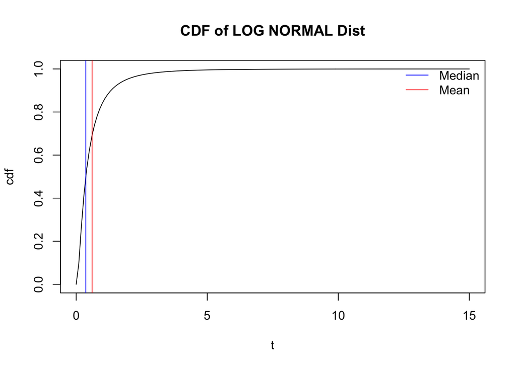

```r
t=seq(0,15,by=0.1)
cdf=plnorm(t,-1,1)
plot(t,cdf,main  = "CDF of LOG NORMAL Dist",type = "l")
abline (v=mean.log,col="red")
abline (v=median.log,col="blue")
legend("topright",c("Median","Mean"), col = c("blue","red"), lwd = 1, bty = "n")
```

To draw figures of the PDF and CDF of LOG NORMAL(*μ*=−1,*σ*=1), I first assign x a sequence randomly, then I use `dlnorm` to plot PDF and `plnorm` to plot CDF. I use the method exp(*σ*<sup>2</sup>/2+*μ*) to calculate the mean of LOG NORMAL(*μ*=−1,*σ*=1), and exp(*μ*) to get the median.

```
*X*∼UNIFORM(0,12)
```

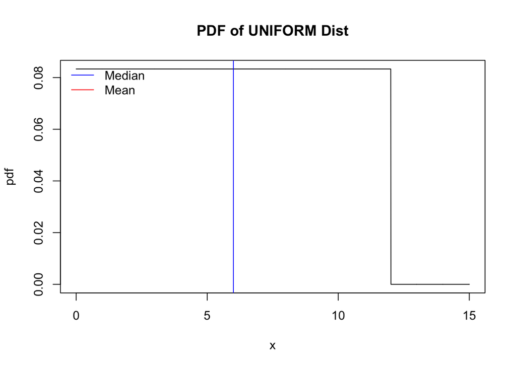

```r
x=seq(0,15,by=0.01)
pdf=dunif(x,min = 0, max = 12)
mean.uni = (0+12)/2
median.uni = (0+12)/2
plot(x,pdf,main  = "PDF of UNIFORM Dist",type = "l")
abline (v=mean.uni,col="red")
abline (v=median.uni,col="blue")
legend("topleft",c("Median","Mean"), col = c("blue","red"), lwd = 1, bty = "n")
```

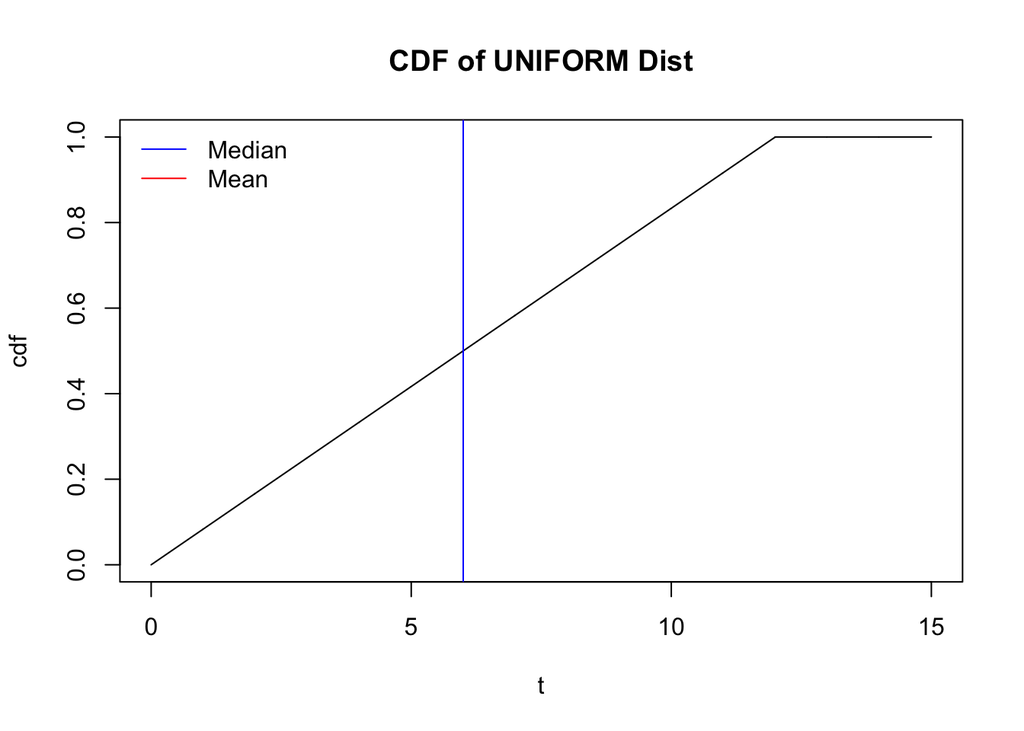

```r
t=seq(0,15,by=0.01)
cdf=punif(t,min = 0, max = 12)
mean.uni = (0+12)/2
median.uni = (0+12)/2
plot(t,cdf,main  = "CDF of UNIFORM Dist",type = "l")
abline (v=mean.uni,col="red")
abline (v=median.uni,col="blue")
legend("topleft",c("Median","Mean"), col = c("blue","red"), lwd = 1, bty = "n")
```

To draw figures of the PDF and CDF of UNIFORM(0,12), and we can know min=0, max=12. First, I assign x a sequence randomly which should bigger than 12, then I use `dunif` to plot PDF and `punif` to plot CDF. I use the method (min+max)/2 to calculate the mean of UNIFORM(0,12), and (min+max)/2 to get the median.

- For each distribution below, generate a figure of the PDF and CDF of the transformation Y = log(X) random variable. Mark the mean and median in the figure. You may use simulation or analytic methods in order find the PDF and CDF of the transformation.

  *X*∼GAMMA(shape=3,scale=1)

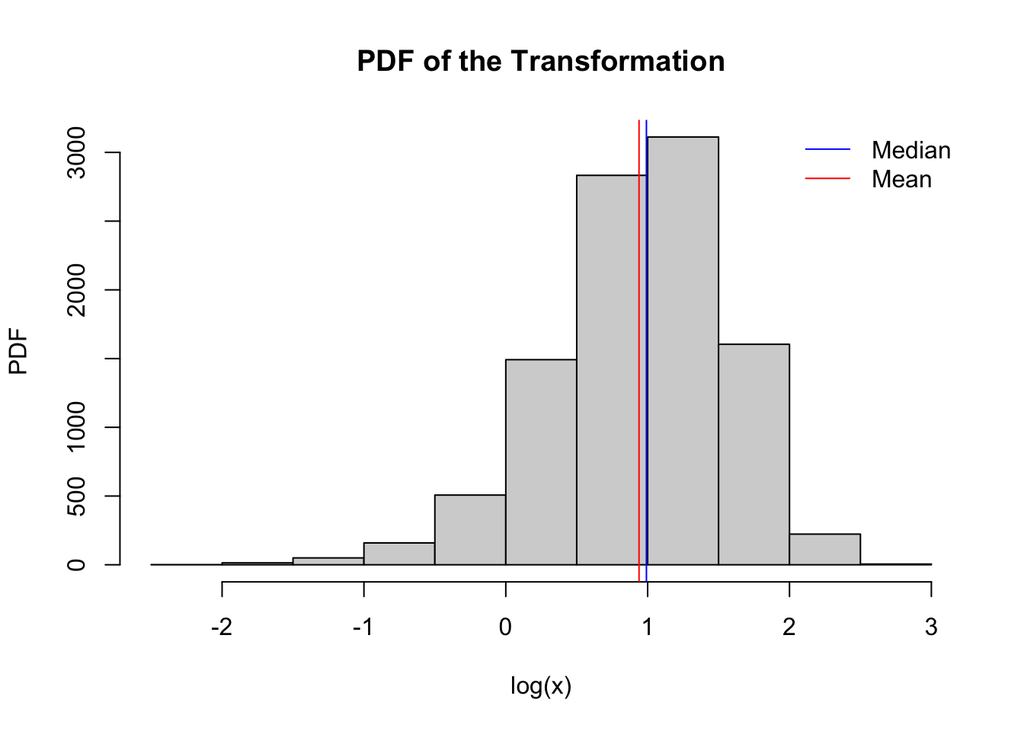

```r
sha=3
sca=1
x=rgamma(10000,sha,sca)
fcdf<-function(x) pgamma(exp(x),shape = sha,scale = sca)
mean.gam = mean(log(x))
median.gam = median(log(x))

hist(log(x),main  = "PDF of the Transformation",ylab="PDF")
abline (v=mean.gam,col="red")
abline (v=median.gam,col="blue")
legend("topright",c("Median","Mean"), col = c("blue","red"), lwd = 1, bty = "n")
```

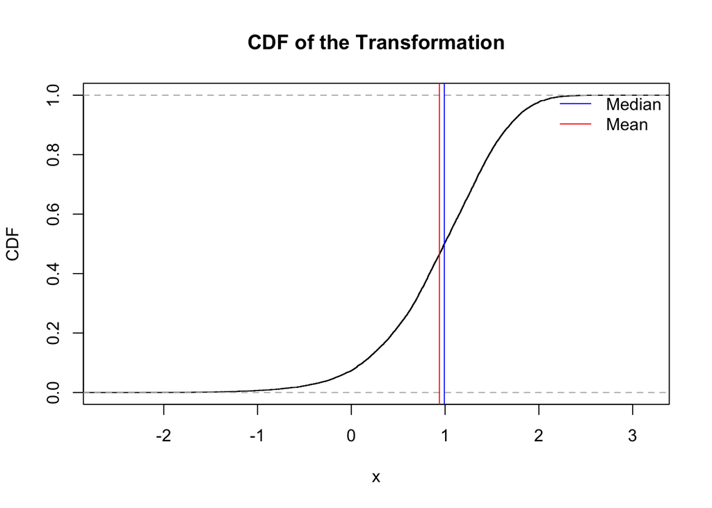

```r
plot(ecdf(log(x)),main  = "CDF of the Transformation",ylab="CDF")
abline (v=mean.gam,col="red")
abline (v=median.gam,col="blue")
legend("topright",c("Median","Mean"), col = c("blue","red"), lwd = 1, bty = "n")
```

```
 *X*∼LOG NORMAL(*μ*=−1,*σ*=1)
```

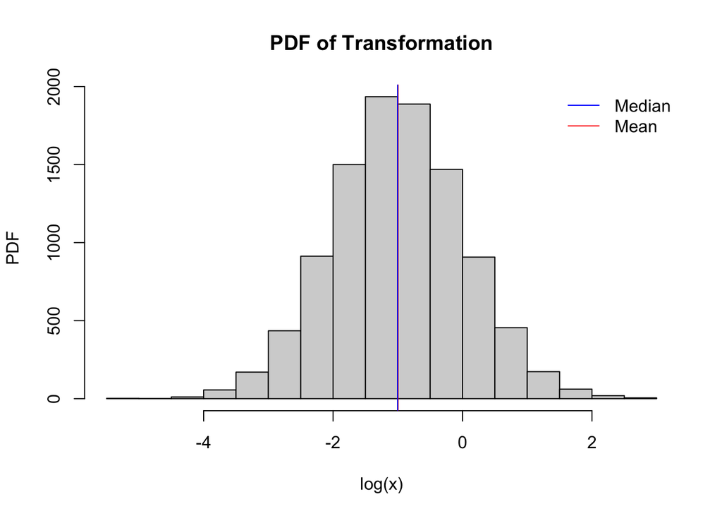

```r
x=rlnorm(10000,-1,1)
mean.log = mean(log(x))
median.log = median(log(x))
hist(log(x),main  = "PDF of Transformation",ylab="PDF")
abline (v=mean.log,col="red")
abline (v=median.log,col="blue")
legend("topright",c("Median","Mean"), col = c("blue","red"), lwd = 1, bty = "n")
```

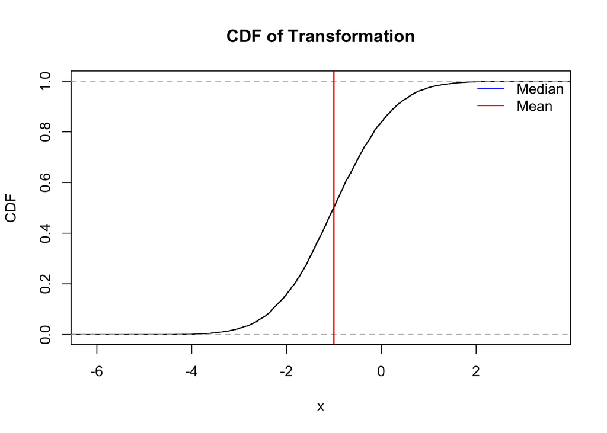

```r
plot(ecdf(log(x)), main  = "CDF of Transformation",ylab="CDF")
abline (v=mean.log,col="red")
abline (v=median.log,col="blue")
legend("topright",c("Median","Mean"), col = c("blue","red"), lwd = 1, bty = "n")
```

```
 *X*∼UNIFORM(0,12)
```

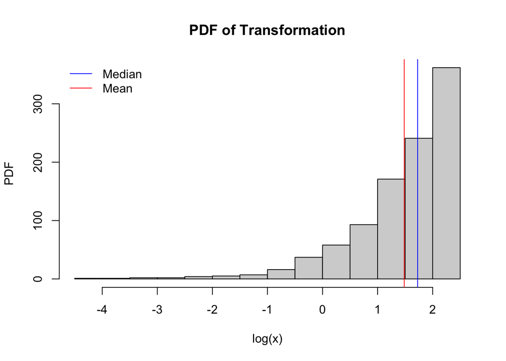

```r
min=0
max=12
x=runif(1000,0,12)

hist(log(x),main  = "PDF of Transformation",ylab="PDF")
fcdf<-function(x) punif(exp(x),min = 0, max = 12)

mean.uni = mean(log(x))
median.uni = median(log(x))
abline (v=mean.uni,col="red")
abline (v=median.uni,col="blue")
legend("topleft",c("Median","Mean"), col = c("blue","red"), lwd = 1, bty = "n")
```

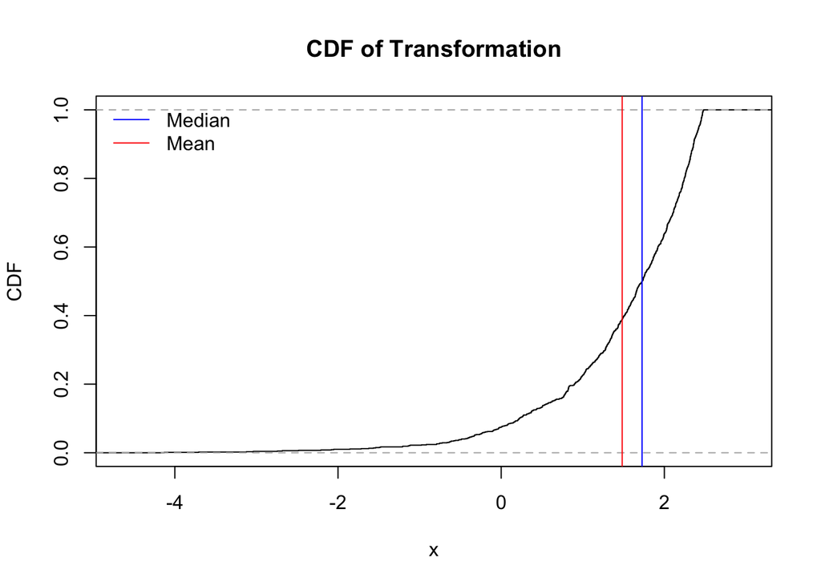

```r
plot(ecdf(log(x)),main  = "CDF of Transformation",ylab="CDF")
abline (v=mean.uni,col="red")
abline (v=median.uni,col="blue")
legend("topleft",c("Median","Mean"), col = c("blue","red"), lwd = 1, bty = "n")
```

- For each of the distributions below, generate 1000 samples of size 100. For each sample, calculate the geometric and arithmetic mean. Generate a scatter plot of the geometic and arithmetic sample means. Add the line of identify as a reference line.

  *X*∼GAMMA(shape=3,scale=1)

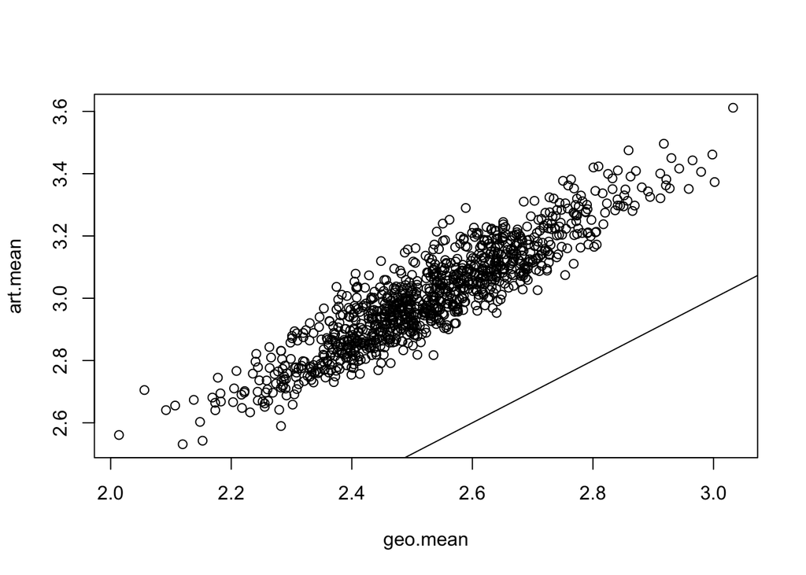

```r
art.mean=NA
geo.mean=NA
for(i in 1:1000){
  d=rgamma(n=100,shape = sha,scale = sca)
  art.mean[i]=mean(d)
  geo.mean[i]=exp(mean(log(d)))
}

plot(geo.mean,art.mean)
abline(0,1)
```

For this question, I calculate the geometic and arithmetic sample means of GAMMA(shape=3,scale=1) using simulation method, I set 1000 as sample size, and the number of observations is 100. I use a loop to find these sample means and use `plot` to draw a figure of them with a line of identify as a reference line.

[output not shown]

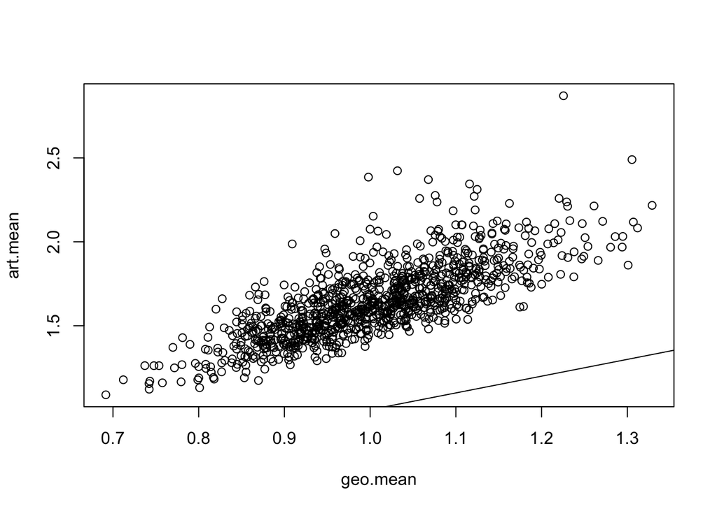

```r
art.mean=NA
geo.mean=NA
for(i in 1:1000){
  d=rlnorm(n=100)
  art.mean[i]=mean(d)
  geo.mean[i]=exp(mean(log(d)))
}

plot(geo.mean,art.mean)
abline(0,1)
```

```
*X*∼UNIFORM(0,12)
```

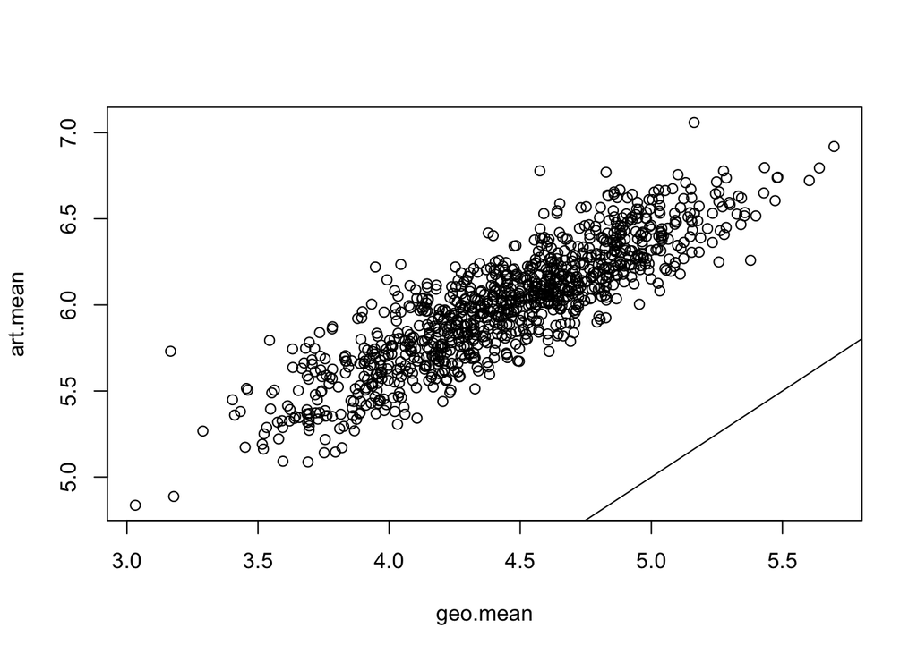

```r
art.mean=NA
geo.mean=NA
for(i in 1:1000){
  d=runif(n=100,min=0,max=12)
  art.mean[i]=mean(d)
  geo.mean[i]=exp(mean(log(d)))
}

plot(geo.mean,art.mean)
abline(0,1)
```

For this question, I calculate the geometic and arithmetic sample means of UNIFORM(0,12) using simulation method, I set 1000 as sample size and the number of observations is 100. I use a loop to find these sample means and use `plot` to draw a figure of them with a line of identify as a reference line.

- Generate a histogram of the difference between the arithmetic mean and the geometric mean.

  *X*∼GAMMA(shape=3,scale=1)

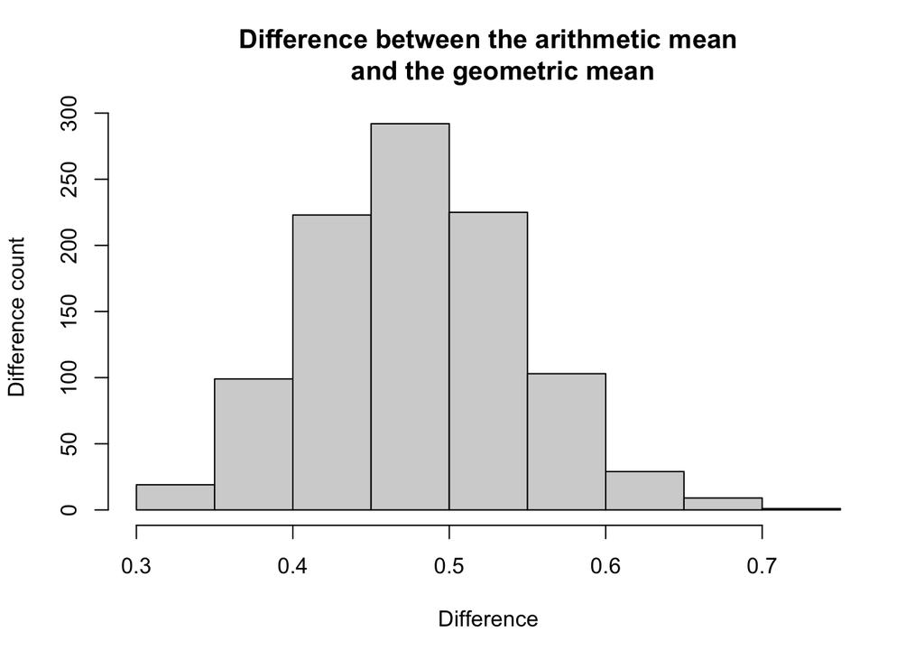

```r
art.mean=NA
geo.mean=NA
for(i in 1:1000){
  d=rgamma(n=100,shape = sha,scale = sca)
  art.mean[i]=mean(d)
  geo.mean[i]=exp(mean(log(d)))
}

hist(art.mean-geo.mean, main="Difference between the arithmetic mean
    and the geometric mean",ylab="Difference count",xlab="Difference")
```

For this question, I also calculate the geometic and arithmetic sample means of GAMMA(shape=3,scale=1) using simulation method, I set 1000 as sample size and the number of observations is 100. I use a loop to find these sample means and use `hist` to draw the difference between the arithmetic mean and the geometric mean. X-axis stands for difference, Y-axis stands for counts of different difference. We can see clearly in this figure that their difference mainly between 0.36-0.6.

[output not shown]

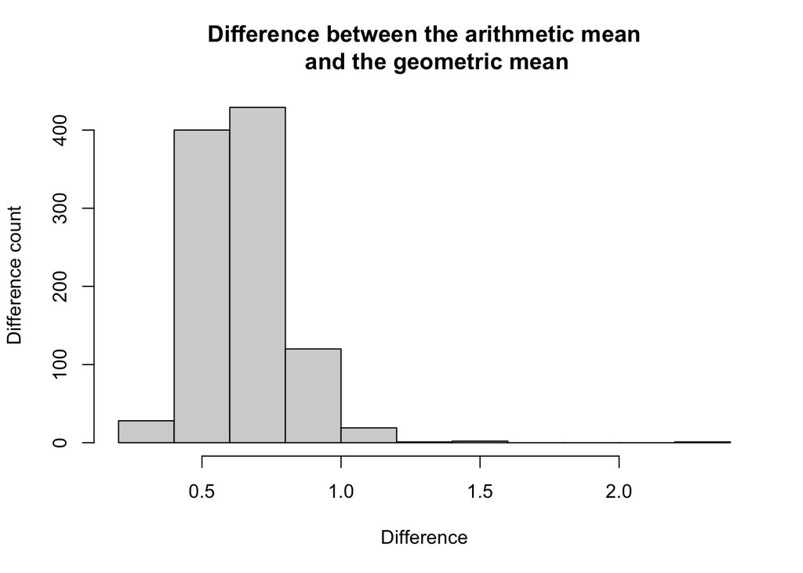

```r
art.mean=NA
geo.mean=NA
for(i in 1:1000){
  d=rlnorm(n=100)
  art.mean[i]=mean(d)
  geo.mean[i]=exp(mean(log(d)))
}

hist(art.mean-geo.mean, main="Difference between the arithmetic mean
    and the geometric mean",ylab="Difference count",xlab="Difference")
```

```
 *X*∼UNIFORM(0,12)
```

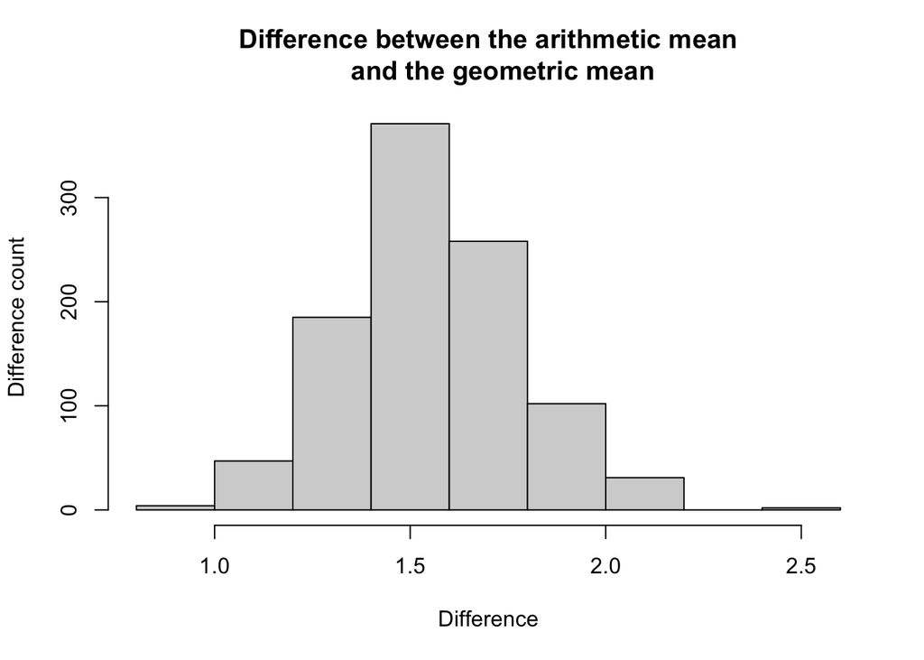

```r
art.mean=NA
geo.mean=NA
for(i in 1:1000){
  d=runif(n=100,min=0,max=12)
  art.mean[i]=mean(d)
  geo.mean[i]=exp(mean(log(d)))
}

hist(art.mean-geo.mean, main="Difference between the arithmetic mean
    and the geometric mean",ylab="Difference count",xlab="Difference")
```

For this question, I calculate the geometic and arithmetic sample means of UNIFORM(0,12) using simulation method, I set 1000 as sample size and the number of observations is 100. I use a loop to find these sample means and use `hist` to draw the difference between the arithmetic mean and the geometric mean. X-axis stands for difference, Y-axis stands for counts of different difference. We can see clearly in this figure that their difference mainly between 1.1-2.

**Distributions**

- *X*∼GAMMA(shape=3,scale=1)

[Interactive plot (link)](https://www.desmos.com/calculator/zt78krngww)

- *X*∼LOG NORMAL(*μ*=−1,*σ*=1)

[Interactive plot (link)](https://www.desmos.com/calculator/ewuwdw5d2a)

- *X*∼UNIFORM(0,12)

## 2.2 Part 2

Show that if *X*<sub>*i*</sub>>0 for all *i*, then the arithmetic mean is greater than or equal to the geometric mean.

Hint: Start with the sample mean of the transformation *Y*<sub>*i*</sub>=log(*X*<sub>*i*</sub>).

```r
art.mean=NA
geo.mean=NA
N<-200
M<-10000
for(i in 1:M){
  d=sample(N,M,replace = TRUE)
  art.mean[i]=mean(d)
  geo.mean[i]=exp(mean(log(d)))
}
unique(ifelse(geo.mean <= art.mean, "arithmetic mean is greater than or equal to the geometric mean." , "geometric mean is greater than arithmetic mean." ))
```

```
## [1] "arithmetic mean is greater than or equal to the geometric mean."
```

For this question, I use simulation method to prove if *X*<sub>*i*</sub>>0 for all *i*, the sample size is 10000 and if arithmetic mean is greater, the code will return “arithmetic mean is greater than or equal to the geometric mean.” I also use the `unique()` to eliminate duplicate results. Then result shows that the arithmetic mean is always greater than or equal to the geometric mean.

## 2.3 Part 3

What is the correct relationship between E[log(X)] and log(E[X])? Is one always larger? Equal? Explain your answer.

```r
ElX=NA
lEX=NA
N<-200
M<-10000

for (i in 1:M) {
  X<-sample(N,M,replace = TRUE)
  ElX[i]<-mean(log(X))
  lEX[i]<-log(mean(X))
}

unique(ifelse(ElX <= lEX, "E[log(X)] is smaller than or equal to log(E[X])" , "E[log(X)] is bigger than log(E[X])" ))
```

```
## [1] "E[log(X)] is smaller than or equal to log(E[X])"
```

To find if this result is correct for any X, we can change the value assigned to M into any number we want, and we can find that it always returns that “E[log(X)] is smaller than or equal to log(E[X])”.